# Statistical Rethinking: Chapter 3

$$Pr(\text{vampire} \mid \text{positive}) = \frac{Pr(\text{positive} \mid \text{vampire}) Pr(\text{vampire})}{Pr(\text{positive})}$$

If the test correctly detects vampirism 95% of the time, then $Pr(\text{positive} \mid \text{vampire}) = 0.95$. The false positive rate is 1% so, $Pr(\text{positive} \mid \text{mortal}) = 0.01$ and only 0.1% of the population is a vampire, $Pr(\text{vampire}) = 0.001$. Given theses probabilities, the probability that you are a vampire given a positive test result is:

```r
PrVP
```

```
[1] 0.08683729
```

# Sampling from a grid-approximate posterior

From the globe tossing example:

```r
n <- 100
# Define Grid
p_grid <- seq(from = 0, to = 1, length.out = n)
# Define Prior
prior <- rep(1, n)
# Compute likelihood at each value in grid
likelihood <- dbinom(x = 6, size = 9, prob = p_grid)
# Compute product of likelihood and proir
unstd.posterior <- likelihood * prior
# Standardize the posterior, so it sums to 1
posterior <- unstd.posterior / sum(unstd.posterior)
```

Now, lets draw 10,000 samples from the posterior:

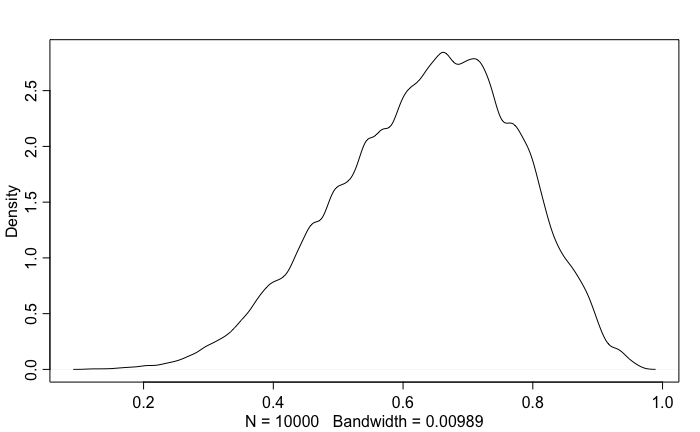

# Sampling to summarize

## Intervals of defined boundaries

What is the posterior probability that the proportion of water is less than 0.5?

```r
# or
sum(samples < 0.5) / 10000
```

```
[1] 0.1746
```

So, 17% of the posterior probability is below 0.5.

How much posterior probability lies between 0.5 and 0.75?

```r
sum(samples > 0.5 & samples < 0.75) / 10000
```

```
[1] 0.6073
```

## Intervals of defined mass

```r
quantile(samples, c(0.1, 0.9))
```

```
      10%       90%
0.4444444 0.8080808
```

Above, we calculated percentile intervals. Percentile intervals communicate the shape of the distribution as long as it is mostly symmetric.

```r
# Percentile interval
PI(samples, prob = 0.5)
```

```
      25%       75%
0.7197197 0.9269269
```

The percentile interval excludes the most probable parameter values. In contrast the Highest Posterior Density Interval (HPDI). The HPDI is the narrowest interval containing the specified probability mass.

```r
HPDI(samples, prob = 0.5)
```

```
     |0.5      0.5|
0.8308308 0.9949950
```

This interval captures the parameters with highest posterior probability.

## Point Estimates

The parameter with the highest posterior probability, a maximum a posteriori (MAP) estimate, can be cumputed as follows:

```r
p_grid[which.max(posterior)]
```

```
[1] 1
```

Or, this value can be approximated:

```r
chainmode(samples, adj = 0.01)
```

```
[1] 0.98411
```

We could also report eh mean or median:

```r
mean(samples)
```

```
[1] 0.8041532
```

```r
median(samples)
```

```
[1] 0.8338338
```

To decide between these, it is good to construct a loss function which tells you the cost associated with using any particular point estimate. Suppose we choose $p = 0.5$ as the decision. Then the weighted average loss is given by:

```r
sum(posterior * abs(0.5 - p_grid))
```

```
[1] 0.3128752
```

To repeat this for every possibly decision, we use:

```r
head(loss)
```

```
[1] 0.8004001 0.7993991 0.7983981 0.7973971 0.7963961 0.7953951
```

`loss` reports a list of loss values, one for each possible decision, corresponding to the values in `p_grid`. With this we can find the parameter that minimizes the loss:

```r
p_grid[which.min(loss)]
```

```
[1] 0.8408408
```

which is the posterior median.

# Sampling to simulate prediction

It is useful to simulate observations from the model used in order to:

1. Check the model: afte a model is fit to data, it is worth simulating implied observations, to check both wether the fit worked correctly and to investigate model behavior.
2. Software validation: In order to be sure that out model fitting software is working, it helps to simulate observations under a known model and then attempt to recover the values of the parameters the data were simulated under.
3. Research design: If you can simulate observations from your hypothesis, then you can evaluate whether the research design can be effective. In a narrow sense, this means doing power analysis, but the possibilities are much broader.
4. Forecasting: Estimates can be used to simulate new predictions, for new cases and future observations. These forecasts can be useful as applied prediction, but also for model criticism and revision.

## Dummy data

Likelihood functions work in both directions. Given a realized observation, the likelihood function says how plausible the observation is. And given only the parameters, the likelihood defines a distribution of possible observations that we can sample from, to simulate observation.

If we suppose that we have 2 tosses, $n = 2$ then there are only 3 possible observations: 0 water, 1 water, and 2 water. We can compute the likelihood of each for any given value of $p$. Let’s use $p = 0.7$.

```r
dbinom(0:2, size = 2, prob = 0.7)
```

```
[1] 0.09 0.42 0.49
```

So, there is a 9% chance of observing $w = 0$, a 42% chance of $w = 1$, and a 49% chance of $w = 2$. We can now simulate observations using these likelihoods:

```r
table(dummy_w) / 100000
```

```
dummy_w
      0       1       2
0.08906 0.42288 0.48806
```

Now let’s simulate 9 tosses of the glode:

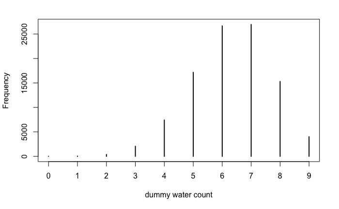

## Model Checking

Model checking means ensuring the model fitting worked correctly and evaluating the adequacy of a model for some purpose.

Every parameter esimate has uncertanty which is the posterior density over $p$. We want to retain that uncertanty when making implied predictions. All we need to do is average over the posterior density for $p$. If we compute the sampling distribuiont of outcomes at each value of $p$, then you could average all of these prediction distributions together, using the posterior probabilities of each value of $p$, to get a posterior predictive distribution.

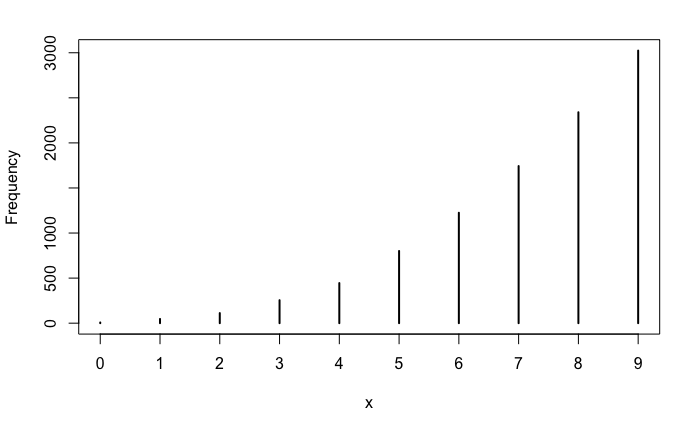